# Your A4 Report Title

## **Section 6: Black & White Prison Population Distribution Across the U.S.**

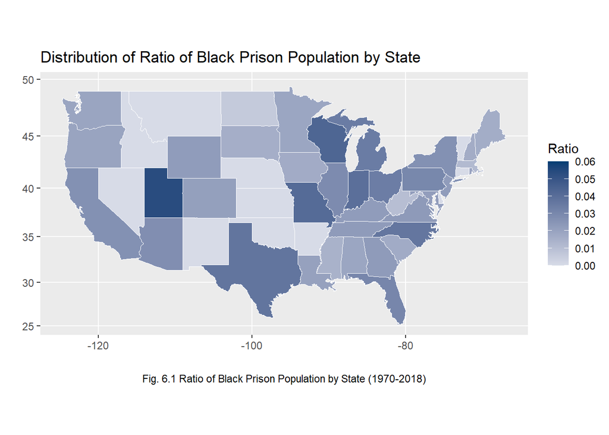

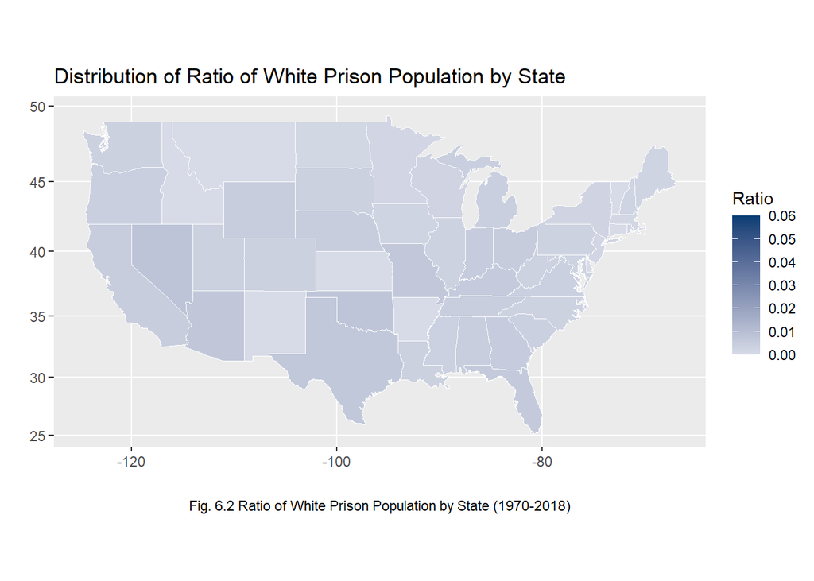

The geographic visualization above shows two figures, figure 6.1 shows the ratio of black prison population by state and figure 6.2 shows the ratio of white prison population by state. The goal of the visualization is to answer the question of how is the black and white prison population ratio distributed across different region in the United States.The charts show that black prison population are more prominent in the mid west and south region of the united states and remain somewhat similar throughout the U.S. for white prison population.